# Pokémon is NP-complete

5/2/2018

# Pokémon is NP-complete

Our project examined the complexity of the first generation of handheld Pokémon video games. Pokémon is a game wherein the player goes on an adventure to collect and battle with wild creatures known as Pokémon, with the goal of defeating increasingly powerful foes. In the proof presented in the paper, the Pokémon game is simplified into two key areas in which the complexity of the game is examined: Trainer battles and traversing the world.

[figure not shown]

When Trainers battle, each one has a team of six Pokémon. The battle is turn-based, and every turn a Pokémon makes a fighting move on the rival Pokemon. Most moves cost PP (Power Points), and every Pokemon has HP (Hit Points) which act as health and decrease each time the Pokémon is hit with an attack. When a Pokémon has no more HP left, it faints and is replaced by another Pokemon on the team with more than 0 HP. The first Trainer to have all six of their Pokemon faint loses, and the other Trainer wins. In the generalized Pokémon presented in the proof, the player can encounter two types of Trainers: strong Trainers (blue in the diagrams) that the player cannot defeat in any circumstances, and weak Trainers (red in the diagrams) that the player can defeat easily.

The paper offers a few proofs regarding the complexity of Pokémon, all of which build off each other to show that it is NP-complete to decide whether a given target location is reachable from a given start location. The paper did this by first proving that Pokémon was in NP and also NP-hard. This is accomplished by utilizing a framework of gadgets, as diagrammed below.

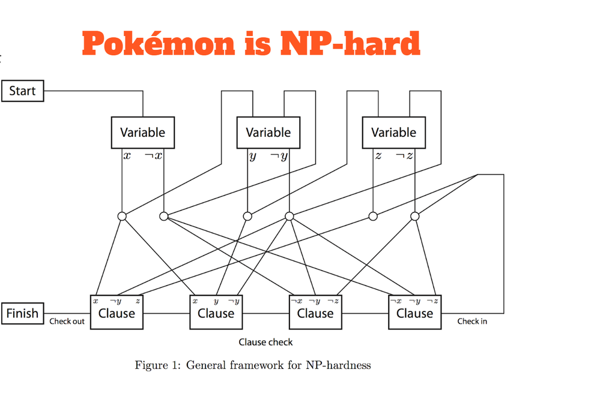

In summary, this framework reduces from the classic NP-complete problem 3-SAT: decide whether a 3-CNF (conjunctive normal form) Boolean formula can be made “true” by setting the variables appropriately. The player’s character starts at the position labeled Start, then proceeds to the Variable gadgets. Each Variable gadget forces the player to make an exclusive choice of “true” (x) or “false” (¬x) value for a variable in the formula, such that once a path is taken, the other path can never be traversed. Either choice enables the player to follow paths leading to Clause gadgets, corresponding to the clauses containing that literal (x or ¬x). These paths may cross each other, but Crossover gadgets prevent the player from switching between crossing paths, so there is no leakage between these paths. The Crossover gadgets work in such a way that two crossing paths must be traversed in one fixed order (one must be traversed before the other, and strictly not the other way around) and each of the two crossing paths can only be traversed in one direction. By visiting a Clause gadget, the player can “unlock” the clause (a permanent state change), but cannot reach any of the other paths connecting to the Clause gadget. Finally, after traversing through all the Variable gadgets, the player must traverse a long “check” path, which passes through each Clause gadget, to reach the Finish position. The player can get through the check path if and only if each clause has been unlocked by some literal. Therefore, it suffices to implement Start, Variable, Clause, Finish, and Crossover gadgets to prove NP-hardness of the game.

So how does this translate into Pokémon?

In the worldspace, each enemy Trainer has an orientation, a range of sight, and a set of Pokémon. As the player traverses the world, they must battle enemy Trainers in order to progress to their destination. These battles are triggered either by walking into an enemy Trainer’s line of sight or by speaking to them directly. We can prove these battles are in NP because each battle is bound in length by a constant. This is due to the fact that each Pokémon only has four different attacks and each attack can only be used a limited number of times (this is the PP mechanic as described above). In the unlikely scenario that both Pokémon in the battle have exhausted their PP without fainting, they must “Struggle” for each turn against the opponent. Struggle reduces the HP of the Pokémon and eventually forces one to faint.

If a player wins the battle then the enemy Trainer will not move or attack again, providing a clear path for the player to proceed. From this we can prove Pokémon’s hardness by using the frame previously explained. We know that Start and Finish gadgets are trivial because they cannot be varied and only have one state.

Let’s look at how this relates to the gadgets described above. The first is the Variable gadget. This forces a player to choose either an a-to-b transversal path or a-to-c transversal path.

[figure not shown]

This is to ensure that no matter what path a player chooses that they are still going to have an interaction with a Trainer. The second is the Clause gadget. This depends on a player’s path and is unlocked whenever a player enters from one of the top paths and talks to one of the three Trainers thereby disabling it. The player must cross the line of sight, and is reached by the strong Trainer if and only if no weak Trainer blocks then, which happens if and only if the Clause gadget is still locked. Similarly, the Crossover gadget is built from a series of single-use paths and forces the player to traverse in a one-way direction through the world through a particular series of crossing paths.

We believe that this proof has little in the way of shortcomings and does a good job of satisfying the initial problem presented. The proof makes sense when when we think about the fact that games are often designed with the goal of getting the user from one point to another, and how difficult that task might be is determined by the “obstacles” that the gamemakers put in the game.

We also believe the proof was effective in its simplification of the Pokémon games without actually reducing their computational complexity. In addition, we appreciated the use of diagrams and believe these are effective in illustrating the relevant information. Additionally, this proof is versatile and can be adapted to explain the complexity of other similar Nintendo games. In fact, the paper makes a similar argument for installments of games like Zelda, Super Mario Bros, and Donkey Kong. We believe that this could be further expanded in the future to cover a wider variety of similar, non-Nintendo games.

Those interested in learning more about this topic and its application can read the original article here: “Classic Nintendo Games are (Computationally) Hard” by Aloupis, Demaine, Guo, and Viglietta. https://arxiv.org/pdf/1203.1895.pdf

Sarah provided introductions to the Pokémon games and the proof itself. Mai discussed the 3-SAT reduction and the various gadgets. Whitney discussed traversing the world and put together the HTML for the web page. Allie discussed Trainer battles, and compiled and edited the content for the web page. Everyone worked together on the assessment and future improvement.